# Exercise 3

Yotam Nir

9 5 2021

### Preface

1. When running OLS or logistic regressions, we have a particular parametric model in mind, and therefore it makes less sense to place exogenous limits on the model’s complexity.
2. Strictly speaking, we cannot (especially if this is done post-hoc). But ‘interpretability’ is in a sense another word for theory, and therefore if we can imagine a mechanism associated with the specified model, this of course increases the likelihood that the model does in fact map a causal relationship.

### Libraries and Data

```r
if (!require("pacman")) install.packages("pacman")
pacman::p_load(tidyverse,
               magrittr,
               tidymodels,
               caret,
               DALEX,
               rpart,
               rattle,
               rpart.plot,
               RColorBrewer,
               ada,
               doParallel,
               pROC,
               e1071,
               gbm,
               randomForest)
heart <- read.csv("C:/Users/user/Dropbox/תשפא/Machine Learning/Machine-Learning-for-Economists/Exercise-2/heart.csv") %>%
  as_tibble() %>%
  mutate(target = as.factor(target))

set.seed(167)
heart_split <- heart %>%
  initial_split(prop = 0.7)
heart_train <- training(heart_split)
heart_test <- testing(heart_split)
```

### Trees

They are path dependent due to the “greedy” algorithm according to which they work. All splits occur within previous splits and do not adjust decisions from previous steps. Trees suffer from overfitting because the choice of splits is driven purely by RSS minimization, which will tend to be unique to particular data sets (and with a larger number of splits this problem is compounded).

```r
formula_part <- target ~ sex + cp + chol
formula_full <- target ~ .
```

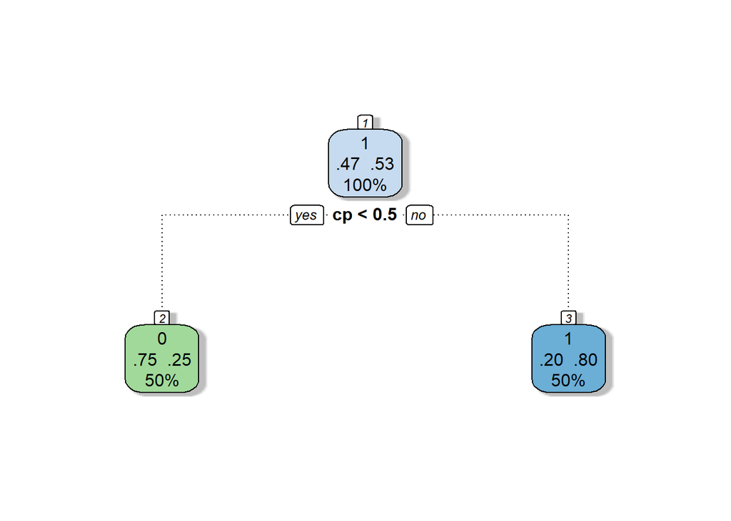

```r
tree_fit <- rpart(
  formula_part,
  data = heart_train,
  method = "class"
)
fancyRpartPlot(tree_fit, caption = NULL)
```

```r
model1 <- rpart(
  formula_full,
  data = heart_train,
  method = "class",
  control = rpart.control(minsplit = 2, minbucket = 1)
)
model2 <- rpart(
  formula_full,
  data = heart_train,
  method = "class"
)
printcp(model1) # uses 9 different variables
```

```
##
## Classification tree:
## rpart(formula = formula_full, data = heart_train, method = "class",
##     control = rpart.control(minsplit = 2, minbucket = 1))
##
## Variables actually used in tree construction:
## [1] age      ca       chol     cp       exang    restecg  thal     thalach
## [9] trestbps
##
## Root node error: 101/213 = 0.47418
##
## n= 213
##
##         CP nsplit rel error  xerror     xstd
## 1 0.534653      0   1.00000 1.00000 0.072154
## 2 0.059406      1   0.46535 0.46535 0.059923
## 3 0.023102      3   0.34653 0.34653 0.053547
## 4 0.019802      6   0.27723 0.41584 0.057493
## 5 0.014851      8   0.23762 0.39604 0.056434
## 6 0.010000     12   0.17822 0.41584 0.057493
```

```r
printcp(model2) # uses 4 different variables
```

```
##
## Classification tree:
## rpart(formula = formula_full, data = heart_train, method = "class")
##
## Variables actually used in tree construction:
## [1] age  ca   cp   thal
##
## Root node error: 101/213 = 0.47418
##
## n= 213
##
##         CP nsplit rel error  xerror     xstd
## 1 0.534653      0   1.00000 1.10891 0.072154
## 2 0.059406      1   0.46535 0.46535 0.059923
## 3 0.014851      3   0.34653 0.34653 0.053547
## 4 0.010000      5   0.31683 0.41584 0.057493
```

The rpart function has higher minimal splits and buckets by default (20 and 7, respectively), and therefore the second model uses less variables than the first (4 and not 9).

```r
# Generating predictions based on both models for train and test sets
pred_model1_train <- predict(model1, heart_train, type = "class")
pred_model2_train <- predict(model2, heart_train, type = "class")
pred_model1_test <- predict(model1, heart_test, type = "class")
pred_model2_test <- predict(model2, heart_test, type = "class")

# Generating corresponding confusion matrices
train_confmat1 <- bind_cols(heart_train$target, pred_model1_train) %>%
  conf_mat(...1, ...2)
train_confmat2 <- bind_cols(heart_train$target, pred_model2_train) %>%
  conf_mat(...1, ...2)
test_confmat1 <- bind_cols(heart_test$target, pred_model1_test) %>%
  conf_mat(...1, ...2)
test_confmat2 <- bind_cols(heart_test$target, pred_model2_test) %>%
  conf_mat(...1, ...2)

# Summarizing confusion matrices' accuracy
train_confmat1 %>%
  summary() %>%
  filter(.metric %in% c("accuracy", "sens", "spec")) %>%
  mutate("1-.estimate" = 1 - .estimate)
```

```
## # A tibble: 3 x 4
##   .metric  .estimator .estimate `1-.estimate`
##   <chr>    <chr>          <dbl>         <dbl>
## 1 accuracy binary         0.915        0.0845
## 2 sens     binary         0.901        0.0990
## 3 spec     binary         0.929        0.0714
```

```r
train_confmat2 %>%
  summary() %>%
  filter(.metric %in% c("accuracy", "sens", "spec")) %>%
  mutate("1-.estimate" = 1 - .estimate)
```

```
## # A tibble: 3 x 4
##   .metric  .estimator .estimate `1-.estimate`
##   <chr>    <chr>          <dbl>         <dbl>
## 1 accuracy binary         0.850         0.150
## 2 sens     binary         0.822         0.178
## 3 spec     binary         0.875         0.125
```

```r
test_confmat1 %>%
  summary() %>%
  filter(.metric %in% c("accuracy", "sens", "spec")) %>%
  mutate("1-.estimate" = 1 - .estimate)
```

```
## # A tibble: 3 x 4
##   .metric  .estimator .estimate `1-.estimate`
##   <chr>    <chr>          <dbl>         <dbl>
## 1 accuracy binary         0.756         0.244
## 2 sens     binary         0.730         0.270
## 3 spec     binary         0.774         0.226
```

```r
test_confmat2 %>%
  summary() %>%
  filter(.metric %in% c("accuracy", "sens", "spec")) %>%
  mutate("1-.estimate" = 1 - .estimate)
```

```
## # A tibble: 3 x 4
##   .metric  .estimator .estimate `1-.estimate`
##   <chr>    <chr>          <dbl>         <dbl>
## 1 accuracy binary         0.767         0.233
## 2 sens     binary         0.757         0.243
## 3 spec     binary         0.774         0.226
```

We can see that the first, more complex model predicts better in the training set, but not in the test set. This probably reflects an overfit from the deeper splits in the first model, which are not well suited to out-of-sample predictions. The second model also suffers from overfit, as can be understood from the lower accuracy of both models w.r.t. the test set.

```r
model1_prune <- prune(model1, cp = 0.03)
model2_prune <- prune(model2, cp = 0.03)
```

First we can note that using the same complexity parameter trims both models down to a level at which they are identical:

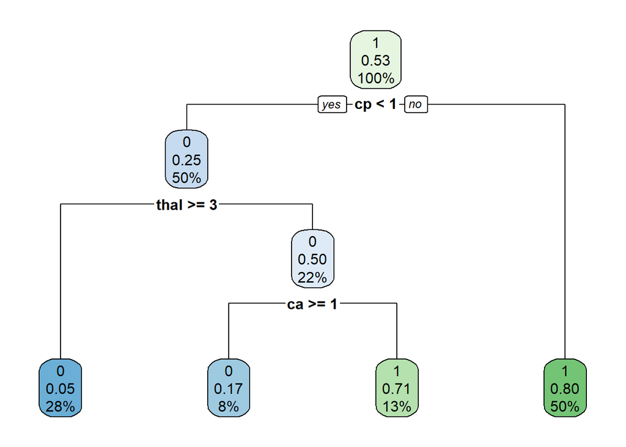

```r
rpart.plot(model1_prune)
rpart.plot(model2_prune)
```

So we can use them interchangeably in prediction:

```r
# Model predictions in train and test sets
pred_prune_train <- predict(model1_prune, heart_train, type = "class")
pred_prune_test <- predict(model1_prune, heart_test, type = "class")

# Generating confusion matrices
train_confmat_prune <- bind_cols(heart_train$target, pred_prune_train) %>%
  conf_mat(...1, ...2)
test_confmat_prune <- bind_cols(heart_test$target, pred_prune_test) %>%
  conf_mat(...1, ...2)

# Summarizing accuracy
train_confmat_prune %>%
  summary() %>%
  filter(.metric %in% c("accuracy", "sens", "spec")) %>%
  mutate("1-.estimate" = 1 - .estimate)
```

```
## # A tibble: 3 x 4
##   .metric  .estimator .estimate `1-.estimate`
##   <chr>    <chr>          <dbl>         <dbl>
## 1 accuracy binary         0.836        0.164
## 2 sens     binary         0.713        0.287
## 3 spec     binary         0.946        0.0536
```

```r
test_confmat_prune %>%
  summary() %>%
  filter(.metric %in% c("accuracy", "sens", "spec")) %>%
  mutate("1-.estimate" = 1 - .estimate)
```

```
## # A tibble: 3 x 4
##   .metric  .estimator .estimate `1-.estimate`
##   <chr>    <chr>          <dbl>         <dbl>
## 1 accuracy binary         0.8          0.2
## 2 sens     binary         0.622        0.378
## 3 spec     binary         0.925        0.0755
```

This time, while the accuracy is still lower w.r.t. the test set, it is very close, suggesting that there is much less overfit.

### K-Nearest Neighbors (KNN)

```r
fitControl <- trainControl(
  method = "repeatedcv",
  number = 5,
  repeats = 3
)
```

### Fitting a Model

```r
KNN <- train(
  formula_full,
  data = heart_train,
  method = "knn",
  trControl = fitControl
)
bagging <- train(
  formula_full,
  data = heart_train,
  method = "ada",
  trControl = fitControl
)
boosting <- train(
  formula_full,
  data = heart_train,
  method = "gbm",
  trControl = fitControl
)
RF <- train(
  formula_full,
  data = heart_train,
  method = "rf",
  trControl = fitControl
)
```

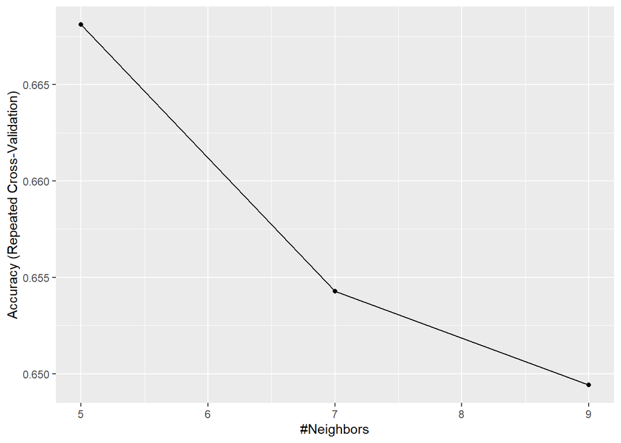

```r
ggplot(KNN)
```

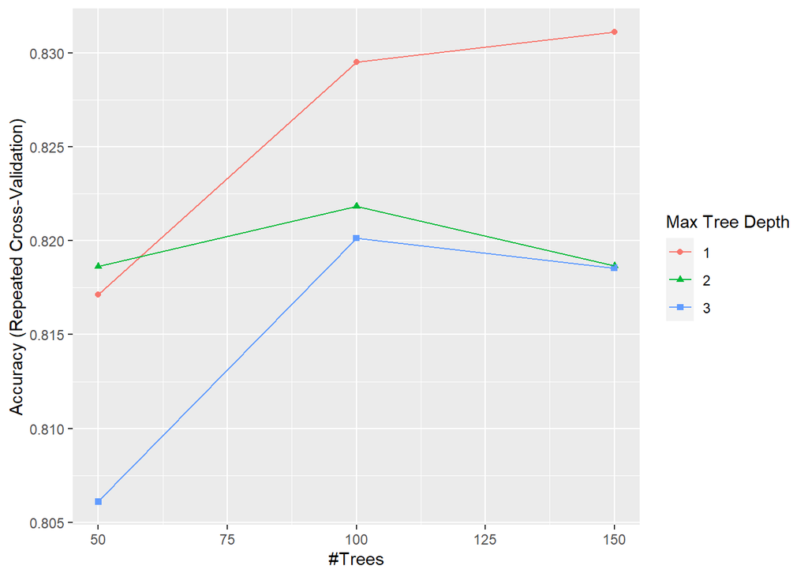

```r
ggplot(bagging)
```

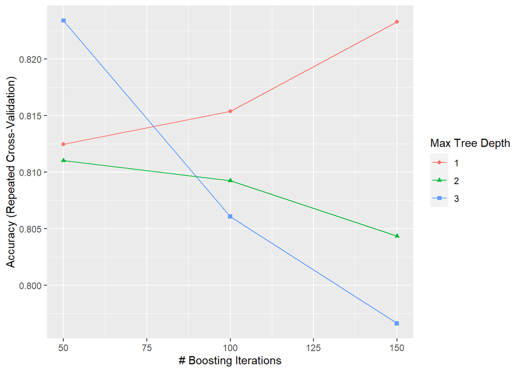

```r
ggplot(boosting)
```

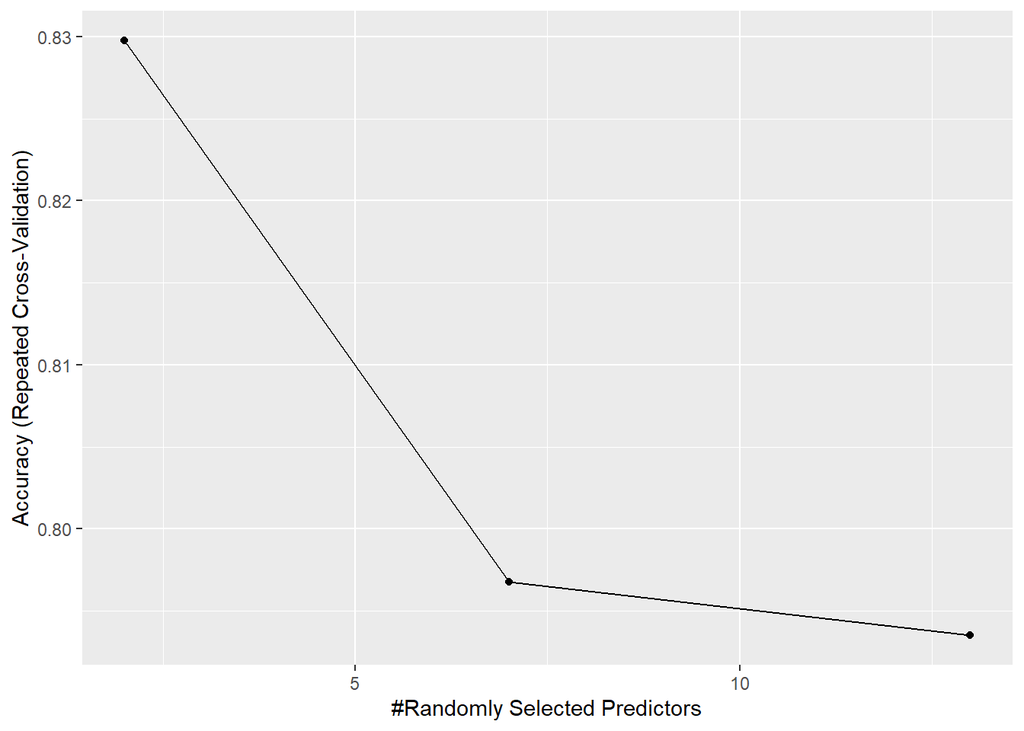

```r
ggplot(RF)
```

```r
expand.grid()
```

```
## data frame with 0 columns and 0 rows
```

### Interpretability

```r
KNN_explainer <- explain(
  KNN,
  label = "model_tag",
  x = heart_train %>% select(-target),
  y = as.numeric(heart_train$target)
)
```

```
## Preparation of a new explainer is initiated
##   -> model label       :  model_tag
##   -> data              :  213  rows  14  cols  extracted from the model
##   -> target variable   :  213  values
##   -> predict function  :  yhat.train  will be used (  default  )
##   -> predicted values  :  No value for predict function target column. (  default  )
##   -> model_info        :  package caret , ver. 6.0.86 , task classification (  default  )
##   -> predicted values  :  numerical, min =  0 , mean =  0.5295775 , max =  1
##   -> residual function :  difference between y and yhat (  default  )
##   -> residuals         :  numerical, min =  0.2 , mean =  0.9962441 , max =  1.8
##   A new explainer has been created!
```

```r
bagging_explainer <- explain(
  bagging,
  label = "model_tag",
  x = heart_train %>% select(-target),
  y = as.numeric(heart_train$target)
)
```

```
## Preparation of a new explainer is initiated
##   -> model label       :  model_tag
##   -> data              :  213  rows  14  cols  extracted from the model
##   -> target variable   :  213  values
##   -> predict function  :  yhat.train  will be used (  default  )
##   -> predicted values  :  No value for predict function target column. (  default  )
##   -> model_info        :  package caret , ver. 6.0.86 , task classification (  default  )
##   -> predicted values  :  numerical, min =  0.007624554 , mean =  0.517073 , max =  0.9893656
##   -> residual function :  difference between y and yhat (  default  )
##   -> residuals         :  numerical, min =  0.05510259 , mean =  1.008749 , max =  1.9367
##   A new explainer has been created!
```

```r
boosting_explainer <- explain(
  boosting,
  label = "model_tag",
  x = heart_train %>% select(-target),
  y = as.numeric(heart_train$target)
)
```

```
## Preparation of a new explainer is initiated
##   -> model label       :  model_tag
##   -> data              :  213  rows  14  cols  extracted from the model
##   -> target variable   :  213  values
##   -> predict function  :  yhat.train  will be used (  default  )
##   -> predicted values  :  No value for predict function target column. (  default  )
##   -> model_info        :  package caret , ver. 6.0.86 , task classification (  default  )
##   -> predicted values  :  numerical, min =  0.01231983 , mean =  0.5300265 , max =  0.9871682
##   -> residual function :  difference between y and yhat (  default  )
##   -> residuals         :  numerical, min =  0.06227828 , mean =  0.9957951 , max =  1.857933
##   A new explainer has been created!
```

```r
RF_explainer <- explain(
  RF,
  label = "model_tag",
  x = heart_train %>% select(-target),
  y = as.numeric(heart_train$target)
)
```

```
## Preparation of a new explainer is initiated
##   -> model label       :  model_tag
##   -> data              :  213  rows  14  cols  extracted from the model
##   -> target variable   :  213  values
##   -> predict function  :  yhat.train  will be used (  default  )
##   -> predicted values  :  No value for predict function target column. (  default  )
##   -> model_info        :  package caret , ver. 6.0.86 , task classification (  default  )
##   -> predicted values  :  numerical, min =  0 , mean =  0.5325446 , max =  0.996
##   -> residual function :  difference between y and yhat (  default  )
##   -> residuals         :  numerical, min =  0.496 , mean =  0.993277 , max =  1.45
##   A new explainer has been created!
```

```r
KNN_mp <- model_performance(KNN_explainer)
bagging_mp <- model_performance(bagging_explainer)
boosting_mp <- model_performance(boosting_explainer)
RF_mp <- model_performance(RF_explainer)
```

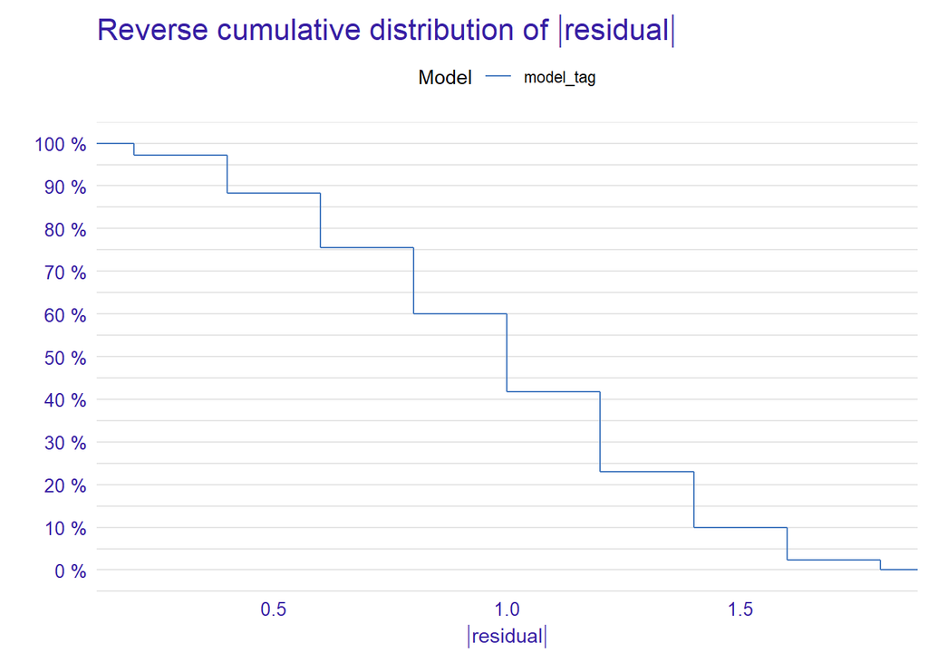

```r
plot(KNN_mp)
```

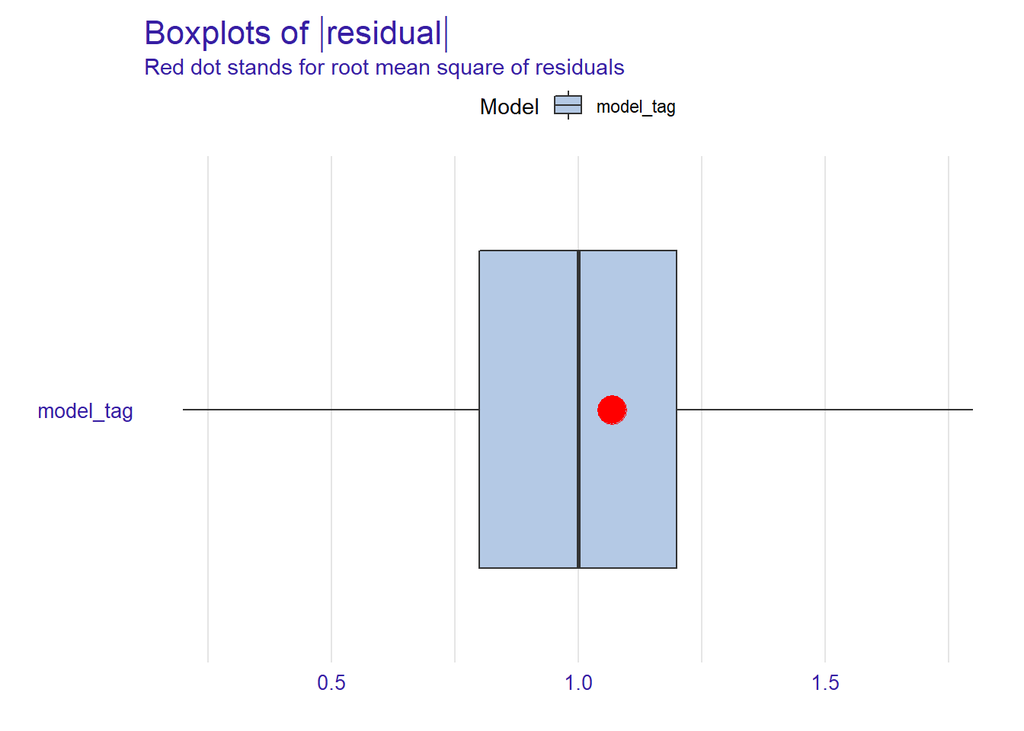

```r
plot(KNN_mp, geom = "boxplot")
```

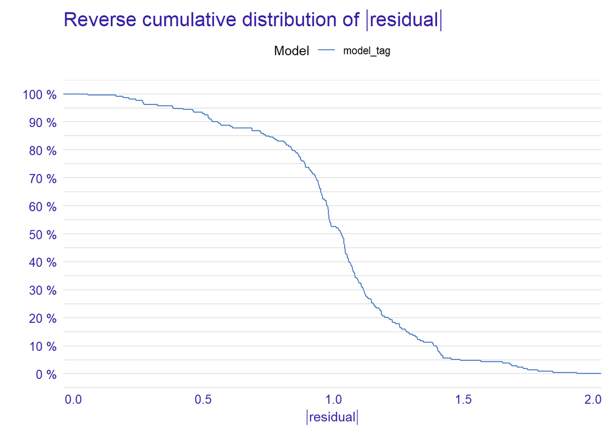

```r
plot(bagging_mp)
```

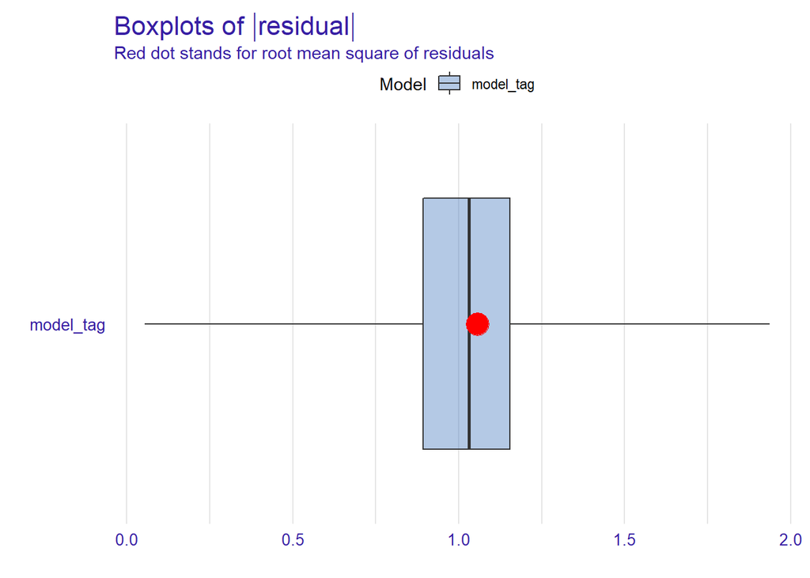

```r
plot(bagging_mp, geom = "boxplot")
```

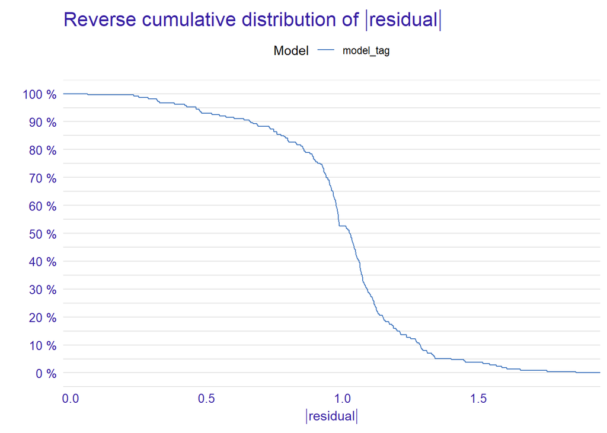

```r
plot(boosting_mp)
```

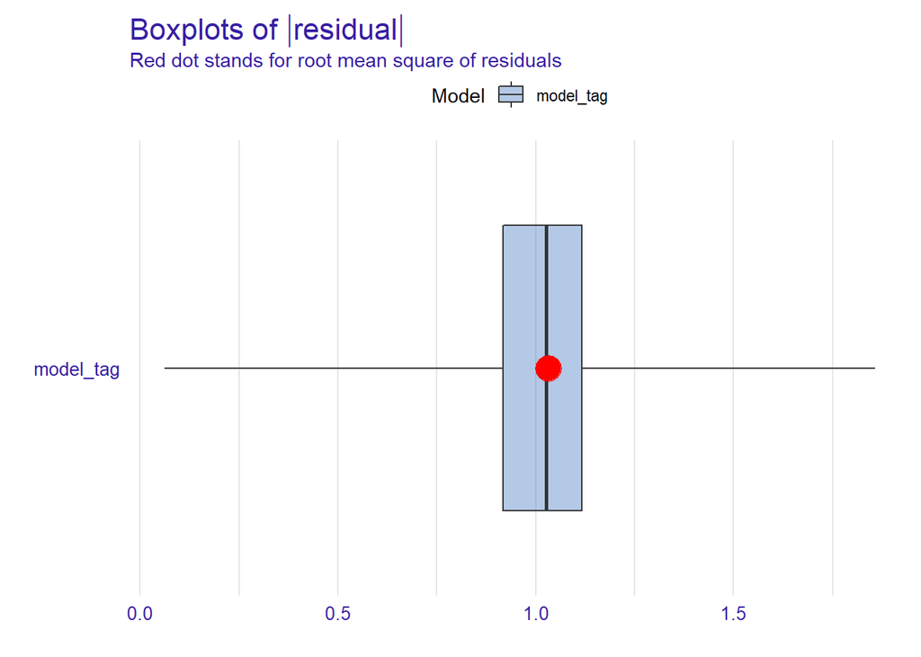

```r
plot(boosting_mp, geom = "boxplot")
```

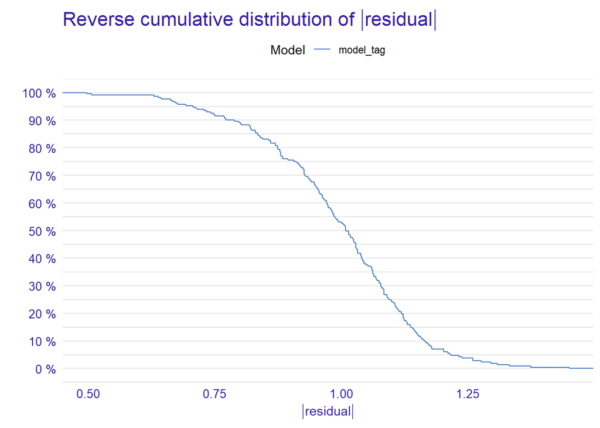

```r
plot(RF_mp)
```

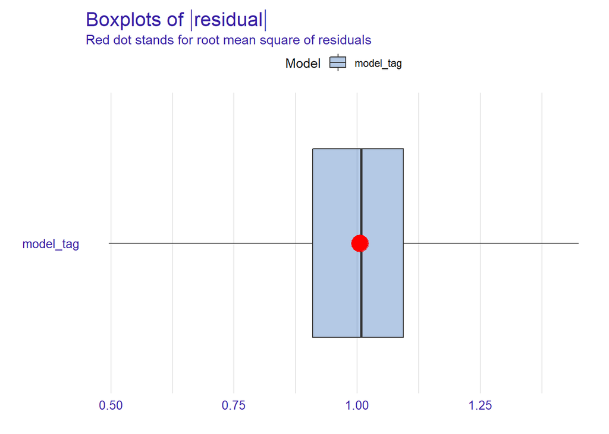

```r
plot(RF_mp, geom = "boxplot")
```

```r
KNN_vip <- variable_importance(KNN_explainer)
bagging_vip <- variable_importance(bagging_explainer)
boosting_vip <- variable_importance(boosting_explainer)
RF_vip <- variable_importance(RF_explainer)
```

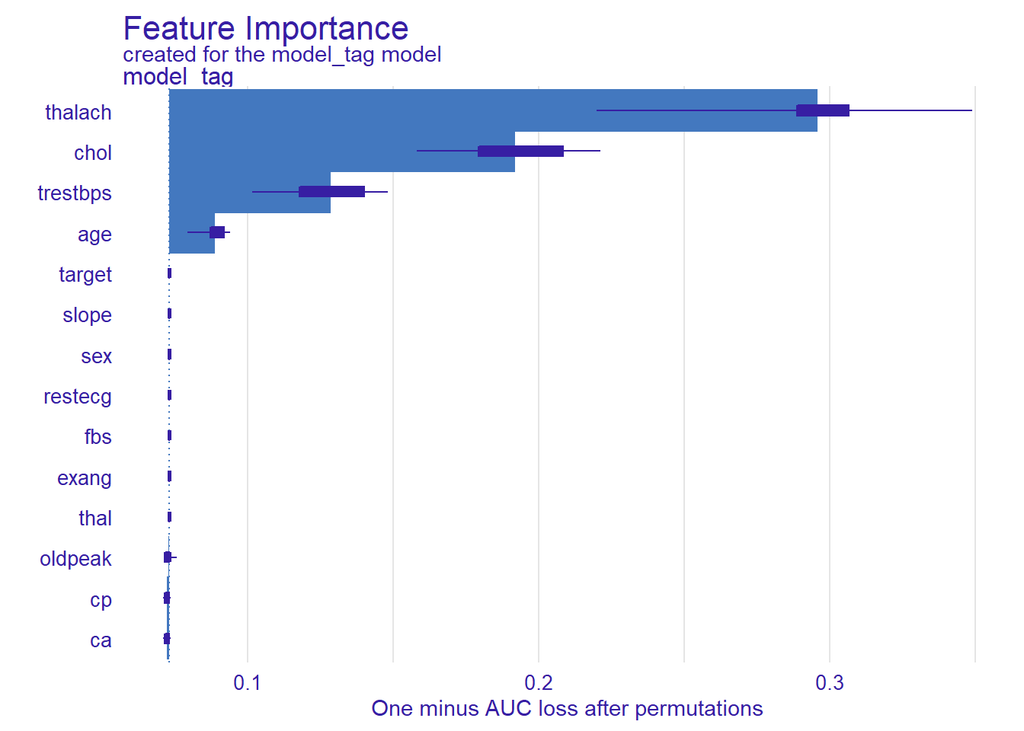

```r
plot(KNN_vip)
```

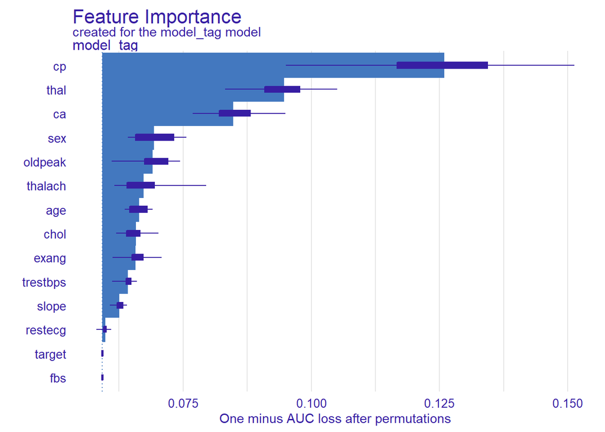

```r
plot(bagging_vip)
```

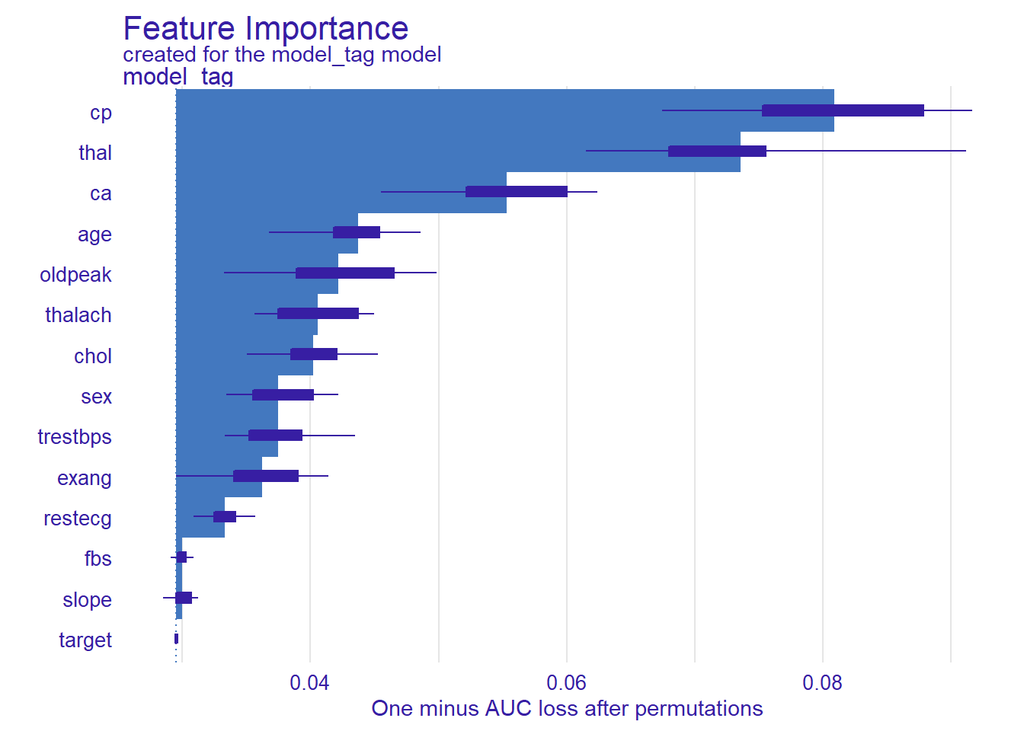

```r
plot(boosting_vip)
```

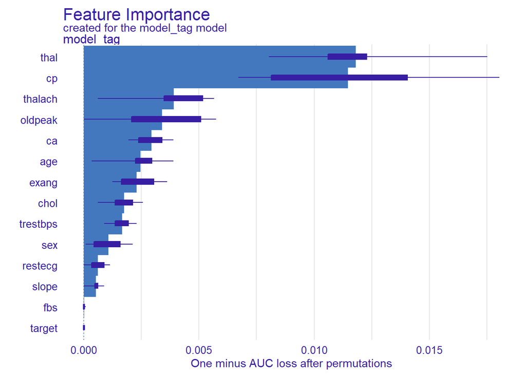

```r
plot(RF_vip)
```

```r
# Note: the 'variable_effect' function is outdated, replaced by 'variable_profile'
KNN_ve <- variable_profile(KNN_explainer)
bagging_ve <- variable_profile(bagging_explainer)
boosting_ve <- variable_profile(boosting_explainer)
RF_ve <- variable_profile(RF_explainer)
```

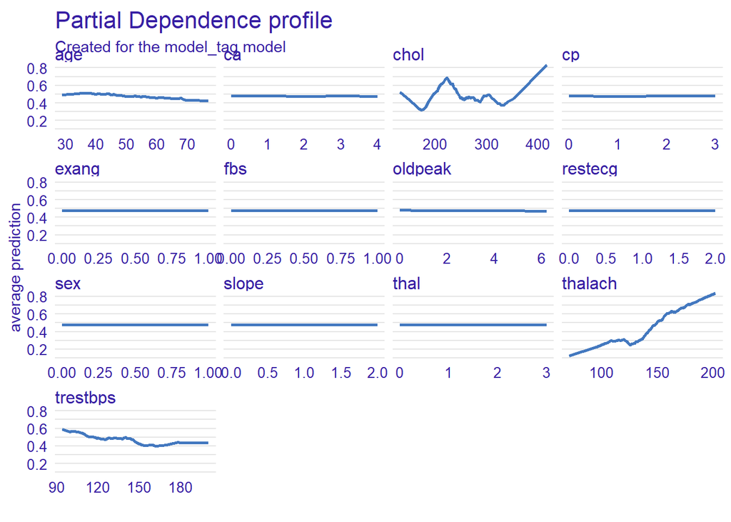

```r
plot(KNN_ve)
```

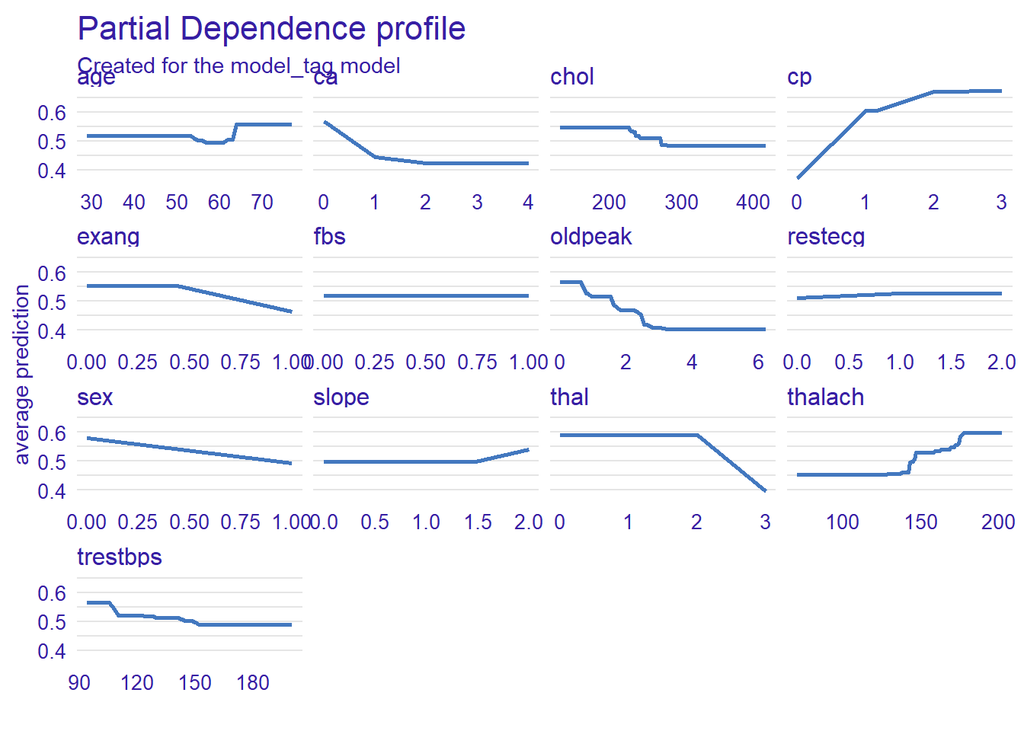

```r
plot(bagging_ve)
```

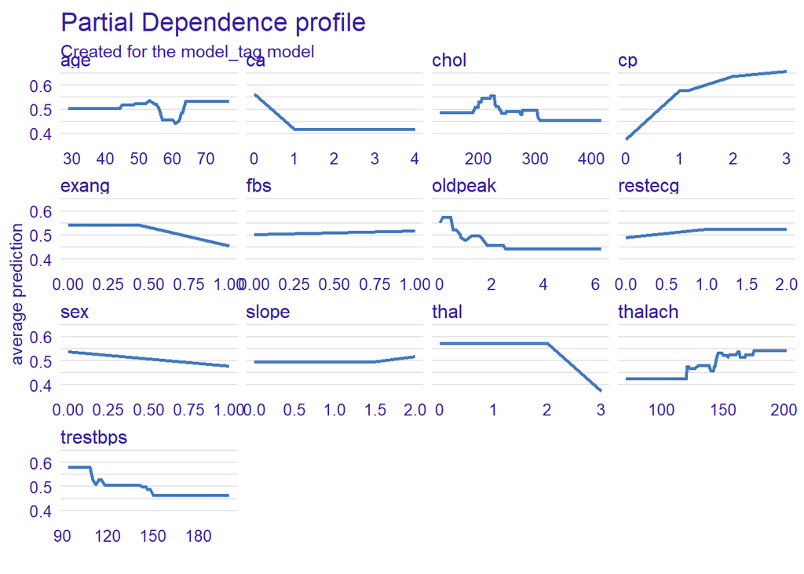

```r
plot(boosting_ve)
```

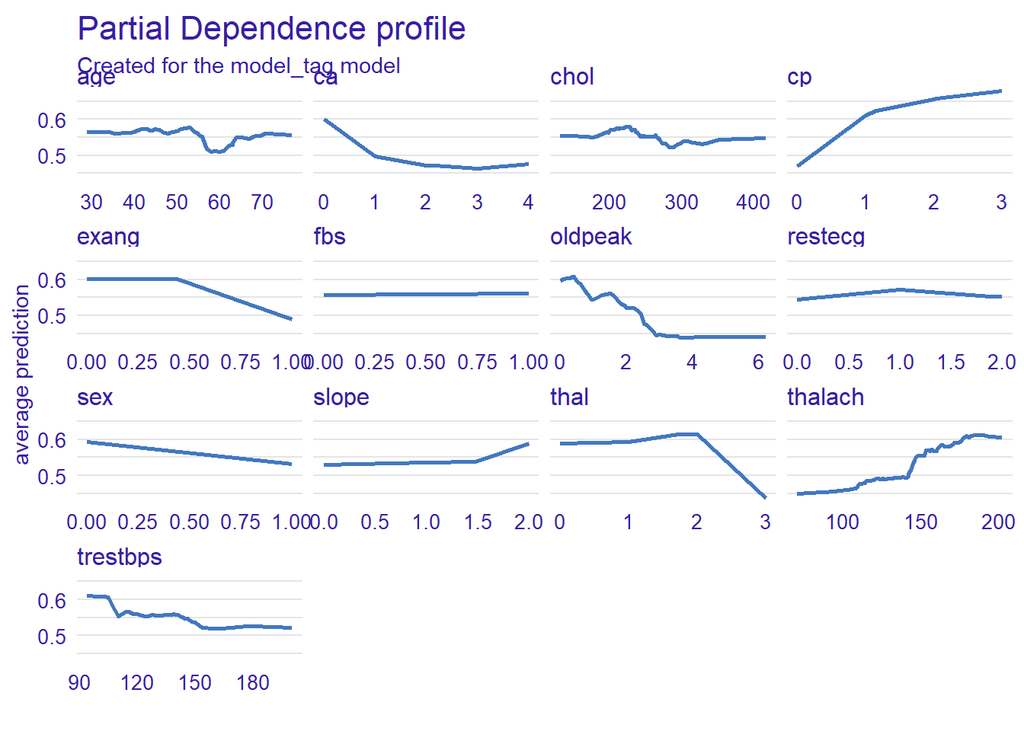

```r
plot(RF_ve)
```

```r
heart_row <- heart_train[1,]
KNN_breakdown <- predict_parts_break_down(KNN_explainer, new_observation = heart_row)
bagging_breakdown <- predict_parts_break_down(bagging_explainer, new_observation = heart_row)
boosting_breakdown <- predict_parts_break_down(boosting_explainer, new_observation = heart_row)
RF_breakdown <- predict_parts_break_down(RF_explainer, new_observation = heart_row)
```

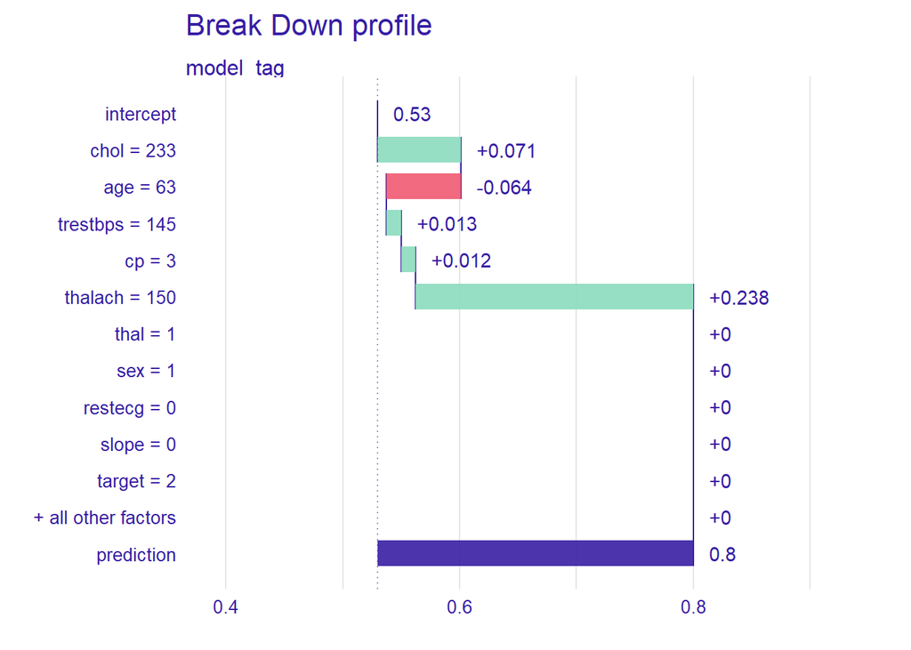

```r
plot(KNN_breakdown)
```

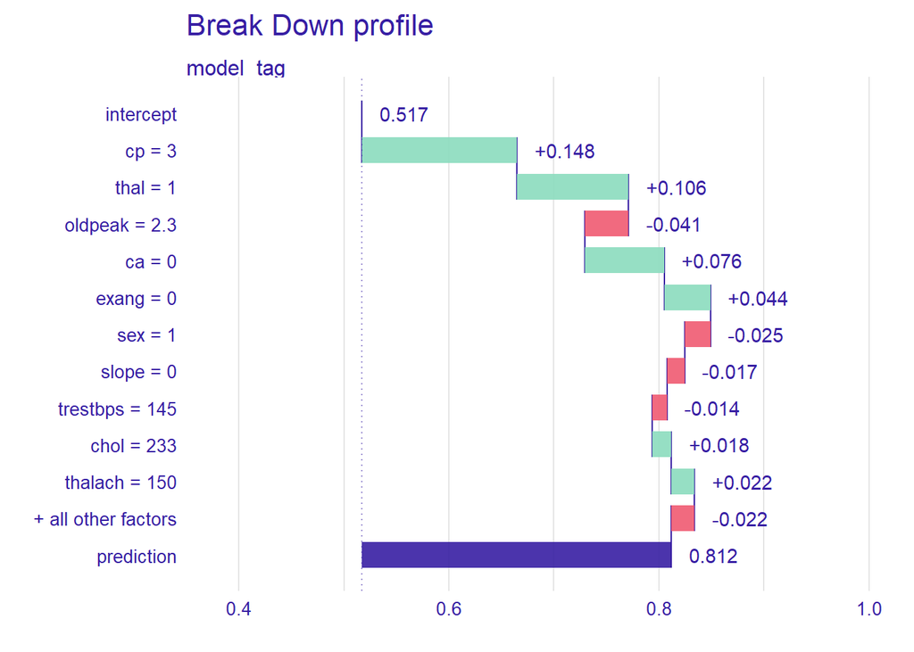

```r
plot(bagging_breakdown)
```

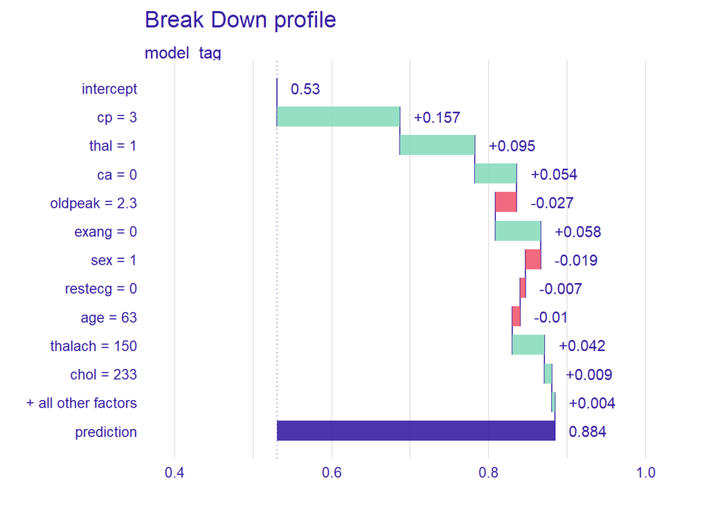

```r
plot(boosting_breakdown)
```

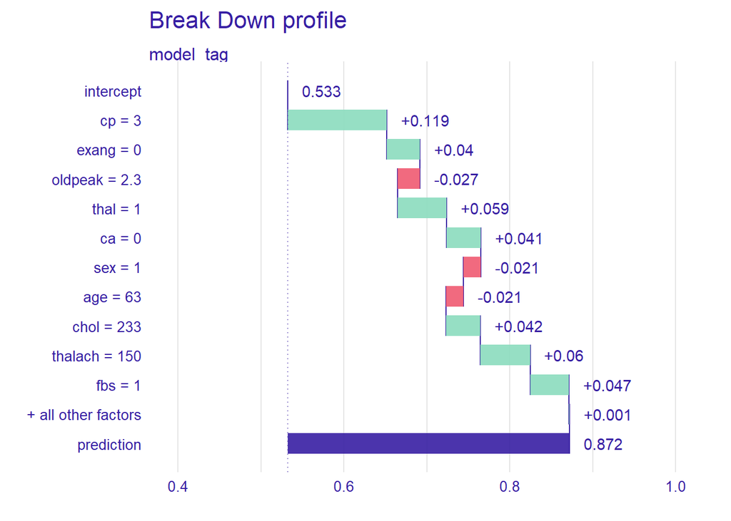

```r
plot(RF_breakdown)
```

```r
KNN_pred <- predict(KNN, newdata = heart_test)
bagging_pred <- predict(bagging, newdata = heart_test)
boosting_pred <- predict(boosting, newdata = heart_test)
RF_pred <- predict(RF, newdata = heart_test)
```

```r
KNN_roc <- bind_cols(heart_test$target, as.numeric(KNN_pred)) %>%
  roc_curve(...1, ...2)
bagging_roc <- bind_cols(heart_test$target, as.numeric(bagging_pred)) %>%
  roc_curve(...1, ...2)
boosting_roc <- bind_cols(heart_test$target, as.numeric(boosting_pred)) %>%
  roc_curve(...1, ...2)
RF_roc <- bind_cols(heart_test$target, as.numeric(RF_pred)) %>%
  roc_curve(...1, ...2)
```

Note: it is not clear to me why my ROC curves are inverted. I am presenting them as they are here, and would appreciate feedback on this.

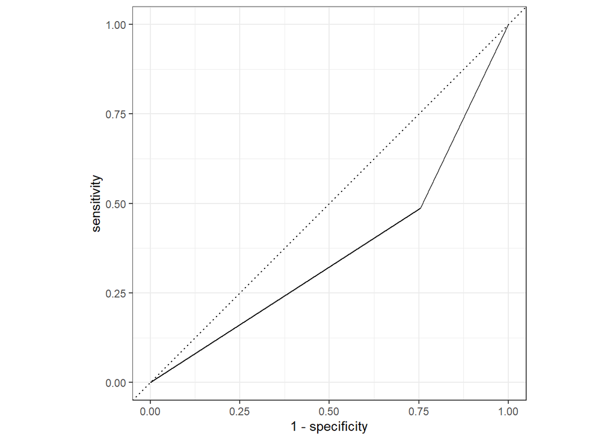

```r
autoplot(KNN_roc)
```

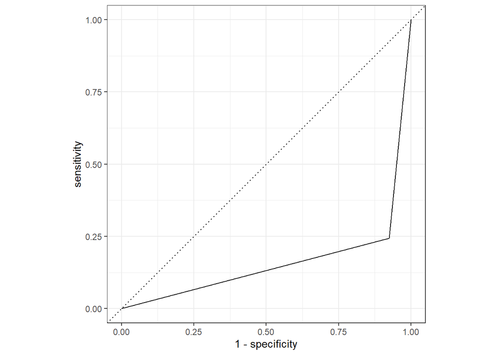

```r
autoplot(bagging_roc)
```

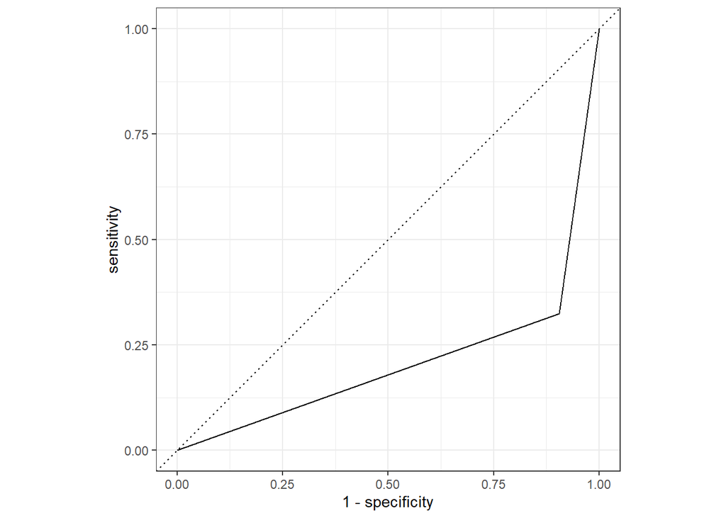

```r
autoplot(boosting_roc)
```

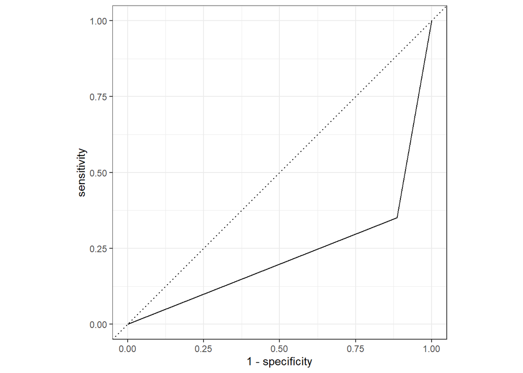

```r
autoplot(RF_roc)
```

```r
bind_cols(heart_test$target, as.numeric(boosting_pred)) %>%
  roc_auc(...1, ...2)
```

```
## # A tibble: 1 x 3
##   .metric .estimator .estimate
##   <chr>   <chr>          <dbl>
## 1 roc_auc binary         0.209
```

The AUC of the boosting model is given by the above function, but its value is incorrect, probably due to the same problem mentioned above.